# AlfalfaHelferNonLinearReport

2023-01-16

```r
library(data.table);
library(drc);
library(tidyr);
library(sommer);
library(nlme);
library(ggplot2);
```

# Looking at Weather of Each of 6 Cuttings:

```r
mat_dap_gdd <- data.frame(fread('2019_Helfer_Alfalfa_DAP_GDD.csv', header=TRUE, sep=','))
mat_dap_gdd$DAP <- as.numeric(mat_dap_gdd$DAP)
mat_dap_gdd$Cutting <- factor(mat_dap_gdd$cut, levels=c("Spring 2020","Spring 2021","Summer 2020","Summer 2021","Fall 2020","Fall 2021"))
```

### Growing Degree Days (GDD) of each cutting, shows that Spring (Cutting 1 and 4) are different than Other Cuttings (Cuttings 2, 3, 5, 6)

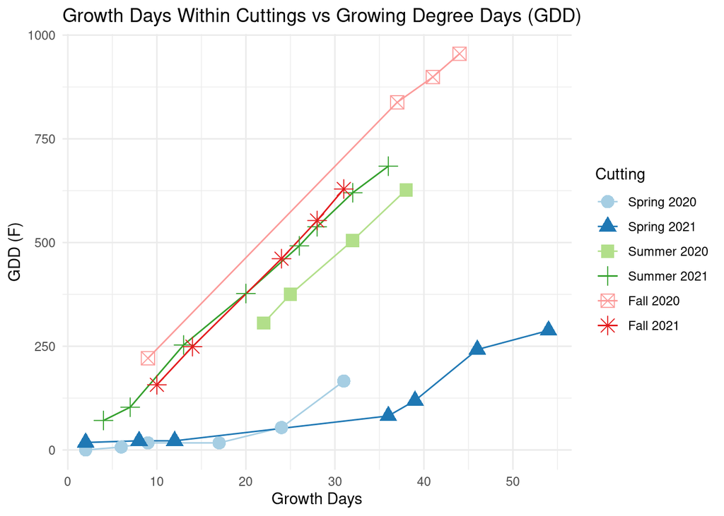

### Cumulative Precipitation (CP) of each cutting

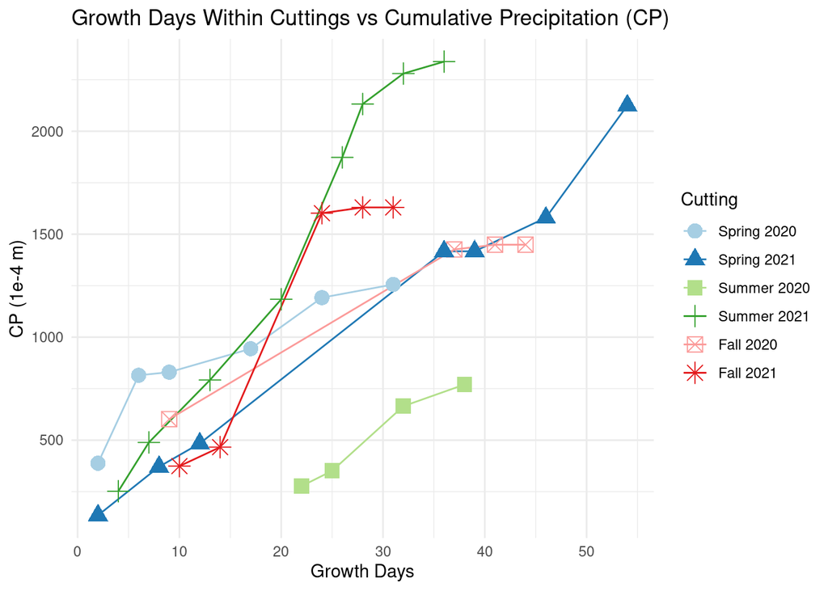

# The Dose Response Model (DRM)

### The drc package has a drm function that can model many functions including 4-parameter logistic regression using L.4

- https://www.statforbiology.com/nonlinearregression/usefulequations#log-logistic_curve

# Read in Helfer field design, harvest data, and NDVI HTP

```r
mat <- data.frame(fread('2019_Helfer_alfalfa_Pix4d_Phenos.csv', header=TRUE, sep=','))
mat$rowNumber <- as.numeric(mat$rowNumber)
mat$colNumber <- as.numeric(mat$colNumber)
```

#### NDVI with good heritability occurred on the following DAP:

```r
ndvi_h2_filtered_dap <- c(
  321, 325, 328, 336, 343, 350, 373, 376, 383, 389, 403, 431, 435, 438, 446, 450, 452, 454, 461, 468, 471,
  671, 677, 681, 705, 708, 715, 723, 740, 743, 749, 756, 762, 764, 768, 772, 786, 790, 800, 804, 807
);
```

#### Splitting the 6 alfalfa cutting/regrowth periods into own dataframes:

#### Reformatting the 6 alfalfa cutting/regrowth periods into long dataframes:

#### Building some combined dataframes for combined analyses:

- The first year consisting of cuts 1 to 3:
- The spring cutting consisting of cuts 1 and 4:
- The non-spring cuttings consisting of cuts 2, 3, 5, and 6:
- All cuttings 1-6:

#### Run Sommer 2D Spline Spatial corrections on all NDVI time points individually:

```r
W <- with(mat, spl2Da(rowNumber, colNumber));
X <- W$Z$`A:all`;

mix_ndvi_2dspl_321 <- mmer(NDVI_321 ~1 + replicate, random=~vs(germplasmName) + spl2Da(rowNumber, colNumber), rcov=~vs(units), data=mat);
blups_2dspl_NDVI_321 <- X %*% mix_ndvi_2dspl_321$U$`A:all`$NDVI_321;

mix_ndvi_2dspl_325 <- mmer(NDVI_325 ~1 + replicate, random=~vs(germplasmName) + spl2Da(rowNumber, colNumber), rcov=~vs(units), data=mat);
blups_2dspl_NDVI_325 <- X %*% mix_ndvi_2dspl_325$U$`A:all`$NDVI_325;

mix_ndvi_2dspl_336 <- mmer(NDVI_336 ~1 + replicate, random=~vs(germplasmName) + spl2Da(rowNumber, colNumber), rcov=~vs(units), data=mat);
blups_2dspl_NDVI_336 <- X %*% mix_ndvi_2dspl_336$U$`A:all`$NDVI_336;

mix_ndvi_2dspl_343 <- mmer(NDVI_343 ~1 + replicate, random=~vs(germplasmName) + spl2Da(rowNumber, colNumber), rcov=~vs(units), data=mat);
blups_2dspl_NDVI_343 <- X %*% mix_ndvi_2dspl_343$U$`A:all`$NDVI_343;

mix_ndvi_2dspl_350 <- mmer(NDVI_350 ~1 + replicate, random=~vs(germplasmName) + spl2Da(rowNumber, colNumber), rcov=~vs(units), data=mat);
blups_2dspl_NDVI_350 <- X %*% mix_ndvi_2dspl_350$U$`A:all`$NDVI_350;

mix_ndvi_2dspl_373 <- mmer(NDVI_373 ~1 + replicate, random=~vs(germplasmName) + spl2Da(rowNumber, colNumber), rcov=~vs(units), data=mat);
blups_2dspl_NDVI_373 <- X %*% mix_ndvi_2dspl_373$U$`A:all`$NDVI_373;

mix_ndvi_2dspl_376 <- mmer(NDVI_376 ~1 + replicate, random=~vs(germplasmName) + spl2Da(rowNumber, colNumber), rcov=~vs(units), data=mat);
blups_2dspl_NDVI_376 <- X %*% mix_ndvi_2dspl_376$U$`A:all`$NDVI_376;

mix_ndvi_2dspl_383 <- mmer(NDVI_383 ~1 + replicate, random=~vs(germplasmName) + spl2Da(rowNumber, colNumber), rcov=~vs(units), data=mat);
blups_2dspl_NDVI_383 <- X %*% mix_ndvi_2dspl_383$U$`A:all`$NDVI_383;

mix_ndvi_2dspl_389 <- mmer(NDVI_389 ~1 + replicate, random=~vs(germplasmName) + spl2Da(rowNumber, colNumber), rcov=~vs(units), data=mat);
blups_2dspl_NDVI_389 <- X %*% mix_ndvi_2dspl_389$U$`A:all`$NDVI_389;

mix_ndvi_2dspl_403 <- mmer(NDVI_403 ~1 + replicate, random=~vs(germplasmName) + spl2Da(rowNumber, colNumber), rcov=~vs(units), data=mat);
blups_2dspl_NDVI_403 <- X %*% mix_ndvi_2dspl_403$U$`A:all`$NDVI_403;

mix_ndvi_2dspl_431 <- mmer(NDVI_431 ~1 + replicate, random=~vs(germplasmName) + spl2Da(rowNumber, colNumber), rcov=~vs(units), data=mat);
blups_2dspl_NDVI_431 <- X %*% mix_ndvi_2dspl_431$U$`A:all`$NDVI_431;

mix_ndvi_2dspl_435 <- mmer(NDVI_435 ~1 + replicate, random=~vs(germplasmName) + spl2Da(rowNumber, colNumber), rcov=~vs(units), data=mat);
blups_2dspl_NDVI_435 <- X %*% mix_ndvi_2dspl_435$U$`A:all`$NDVI_435;

mix_ndvi_2dspl_438 <- mmer(NDVI_438 ~1 + replicate, random=~vs(germplasmName) + spl2Da(rowNumber, colNumber), rcov=~vs(units), data=mat);
blups_2dspl_NDVI_438 <- X %*% mix_ndvi_2dspl_438$U$`A:all`$NDVI_438;

mix_ndvi_2dspl_671 <- mmer(NDVI_671 ~1 + replicate, random=~vs(germplasmName) + spl2Da(rowNumber, colNumber), rcov=~vs(units), data=mat);
blups_2dspl_NDVI_671 <- X %*% mix_ndvi_2dspl_671$U$`A:all`$NDVI_671;

mix_ndvi_2dspl_677 <- mmer(NDVI_677 ~1 + replicate, random=~vs(germplasmName) + spl2Da(rowNumber, colNumber), rcov=~vs(units), data=mat);
blups_2dspl_NDVI_677 <- X %*% mix_ndvi_2dspl_677$U$`A:all`$NDVI_677;

mix_ndvi_2dspl_681 <- mmer(NDVI_681 ~1 + replicate, random=~vs(germplasmName) + spl2Da(rowNumber, colNumber), rcov=~vs(units), data=mat);
blups_2dspl_NDVI_681 <- X %*% mix_ndvi_2dspl_681$U$`A:all`$NDVI_681;

mix_ndvi_2dspl_705 <- mmer(NDVI_705 ~1 + replicate, random=~vs(germplasmName) + spl2Da(rowNumber, colNumber), rcov=~vs(units), data=mat);
blups_2dspl_NDVI_705 <- X %*% mix_ndvi_2dspl_705$U$`A:all`$NDVI_705;

mix_ndvi_2dspl_708 <- mmer(NDVI_708 ~1 + replicate, random=~vs(germplasmName) + spl2Da(rowNumber, colNumber), rcov=~vs(units), data=mat);
blups_2dspl_NDVI_708 <- X %*% mix_ndvi_2dspl_708$U$`A:all`$NDVI_708;

mix_ndvi_2dspl_715 <- mmer(NDVI_715 ~1 + replicate, random=~vs(germplasmName) + spl2Da(rowNumber, colNumber), rcov=~vs(units), data=mat);
blups_2dspl_NDVI_715 <- X %*% mix_ndvi_2dspl_715$U$`A:all`$NDVI_715;

mix_ndvi_2dspl_723 <- mmer(NDVI_723 ~1 + replicate, random=~vs(germplasmName) + spl2Da(rowNumber, colNumber), rcov=~vs(units), data=mat);
blups_2dspl_NDVI_723 <- X %*% mix_ndvi_2dspl_723$U$`A:all`$NDVI_723;

mix_ndvi_2dspl_740 <- mmer(NDVI_740 ~1 + replicate, random=~vs(germplasmName) + spl2Da(rowNumber, colNumber), rcov=~vs(units), data=mat);
blups_2dspl_NDVI_740 <- X %*% mix_ndvi_2dspl_740$U$`A:all`$NDVI_740;

mix_ndvi_2dspl_743 <- mmer(NDVI_743 ~1 + replicate, random=~vs(germplasmName) + spl2Da(rowNumber, colNumber), rcov=~vs(units), data=mat);
blups_2dspl_NDVI_743 <- X %*% mix_ndvi_2dspl_743$U$`A:all`$NDVI_743;

mix_ndvi_2dspl_749 <- mmer(NDVI_749 ~1 + replicate, random=~vs(germplasmName) + spl2Da(rowNumber, colNumber), rcov=~vs(units), data=mat);
blups_2dspl_NDVI_749 <- X %*% mix_ndvi_2dspl_749$U$`A:all`$NDVI_749;

mix_ndvi_2dspl_756 <- mmer(NDVI_756 ~1 + replicate, random=~vs(germplasmName) + spl2Da(rowNumber, colNumber), rcov=~vs(units), data=mat);
blups_2dspl_NDVI_756 <- X %*% mix_ndvi_2dspl_756$U$`A:all`$NDVI_756;

mix_ndvi_2dspl_762 <- mmer(NDVI_762 ~1 + replicate, random=~vs(germplasmName) + spl2Da(rowNumber, colNumber), rcov=~vs(units), data=mat);
blups_2dspl_NDVI_762 <- X %*% mix_ndvi_2dspl_762$U$`A:all`$NDVI_762;

mix_ndvi_2dspl_768 <- mmer(NDVI_768 ~1 + replicate, random=~vs(germplasmName) + spl2Da(rowNumber, colNumber), rcov=~vs(units), data=mat);
blups_2dspl_NDVI_768 <- X %*% mix_ndvi_2dspl_768$U$`A:all`$NDVI_768;

mix_ndvi_2dspl_772 <- mmer(NDVI_772 ~1 + replicate, random=~vs(germplasmName) + spl2Da(rowNumber, colNumber), rcov=~vs(units), data=mat);
blups_2dspl_NDVI_772 <- X %*% mix_ndvi_2dspl_772$U$`A:all`$NDVI_772;

mix_ndvi_2dspl_786 <- mmer(NDVI_786 ~1 + replicate, random=~vs(germplasmName) + spl2Da(rowNumber, colNumber), rcov=~vs(units), data=mat);
blups_2dspl_NDVI_786 <- X %*% mix_ndvi_2dspl_786$U$`A:all`$NDVI_786;

mix_ndvi_2dspl_790 <- mmer(NDVI_790 ~1 + replicate, random=~vs(germplasmName) + spl2Da(rowNumber, colNumber), rcov=~vs(units), data=mat);
blups_2dspl_NDVI_790 <- X %*% mix_ndvi_2dspl_790$U$`A:all`$NDVI_790;

mix_ndvi_2dspl_800 <- mmer(NDVI_800 ~1 + replicate, random=~vs(germplasmName) + spl2Da(rowNumber, colNumber), rcov=~vs(units), data=mat);
blups_2dspl_NDVI_800 <- X %*% mix_ndvi_2dspl_800$U$`A:all`$NDVI_800;

mix_ndvi_2dspl_804 <- mmer(NDVI_804 ~1 + replicate, random=~vs(germplasmName) + spl2Da(rowNumber, colNumber), rcov=~vs(units), data=mat);
blups_2dspl_NDVI_804 <- X %*% mix_ndvi_2dspl_804$U$`A:all`$NDVI_804;

mix_ndvi_2dspl_807 <- mmer(NDVI_807 ~1 + replicate, random=~vs(germplasmName) + spl2Da(rowNumber, colNumber), rcov=~vs(units), data=mat);
blups_2dspl_NDVI_807 <- X %*% mix_ndvi_2dspl_807$U$`A:all`$NDVI_807;
```

#### For each cut collect the spatially corrected NDVI plot level values by subtracting spatial effect from NDVI:

#### Foreach cut reformat the spatially corrected NDVI into a long datatable with time as numeric DAP:

#### Foreach of the 6 cuttings and foreach field plot run L.4 DRM, extract the L.4 coefficient values, and extract the predicted L.4 values across time:

#### Foreach cutting save each plot’s L.4 coefficients:

#### Make combined dataframes of each plot’s L.4 coefficients:

- This dataframe has L.4 coefficients for all 6 cuttings:
- This dataframe has L.4 coefficients for the Spring (Env1) cuttings 1 and 4:
- This dataframe has L.4 coefficients for the non-spring (Env2) cuttings 2, 3, 5, and 6:

### Foreach cutting, and Env1 and Env2, calculate BLUPS for genetic effect of each plot’s L.4 coefficients:

```r
ndvi_2dspl_corrected_cut1_l4_b_mix <- mmer(l4_coeff_b_cut1~1 + replicate, random=~vs(id), rcov=~vs(units), data=mat_ndvi_2dspl_corrected_cut1);
ndvi_2dspl_corrected_cut1_l4_c_mix <- mmer(l4_coeff_c_cut1~1 + replicate, random=~vs(id), rcov=~vs(units), data=mat_ndvi_2dspl_corrected_cut1);
ndvi_2dspl_corrected_cut1_l4_d_mix <- mmer(l4_coeff_d_cut1~1 + replicate, random=~vs(id), rcov=~vs(units), data=mat_ndvi_2dspl_corrected_cut1);
ndvi_2dspl_corrected_cut1_l4_e_mix <- mmer(l4_coeff_e_cut1~1 + replicate, random=~vs(id), rcov=~vs(units), data=mat_ndvi_2dspl_corrected_cut1);

ndvi_2dspl_corrected_cut2_l4_b_mix <- mmer(l4_coeff_b_cut2~1 + replicate, random=~vs(id), rcov=~vs(units), data=mat_ndvi_2dspl_corrected_cut2);
ndvi_2dspl_corrected_cut2_l4_c_mix <- mmer(l4_coeff_c_cut2~1 + replicate, random=~vs(id), rcov=~vs(units), data=mat_ndvi_2dspl_corrected_cut2);
ndvi_2dspl_corrected_cut2_l4_d_mix <- mmer(l4_coeff_d_cut2~1 + replicate, random=~vs(id), rcov=~vs(units), data=mat_ndvi_2dspl_corrected_cut2);
ndvi_2dspl_corrected_cut2_l4_e_mix <- mmer(l4_coeff_e_cut2~1 + replicate, random=~vs(id), rcov=~vs(units), data=mat_ndvi_2dspl_corrected_cut2);

ndvi_2dspl_corrected_cut3_l4_b_mix <- mmer(l4_coeff_b_cut3~1 + replicate, random=~vs(id), rcov=~vs(units), data=mat_ndvi_2dspl_corrected_cut3);
ndvi_2dspl_corrected_cut3_l4_c_mix <- mmer(l4_coeff_c_cut3~1 + replicate, random=~vs(id), rcov=~vs(units), data=mat_ndvi_2dspl_corrected_cut3);
ndvi_2dspl_corrected_cut3_l4_d_mix <- mmer(l4_coeff_d_cut3~1 + replicate, random=~vs(id), rcov=~vs(units), data=mat_ndvi_2dspl_corrected_cut3);
ndvi_2dspl_corrected_cut3_l4_e_mix <- mmer(l4_coeff_e_cut3~1 + replicate, random=~vs(id), rcov=~vs(units), data=mat_ndvi_2dspl_corrected_cut3);

ndvi_2dspl_corrected_cut4_l4_b_mix <- mmer(l4_coeff_b_cut4~1 + replicate, random=~vs(id), rcov=~vs(units), data=mat_ndvi_2dspl_corrected_cut4);
ndvi_2dspl_corrected_cut4_l4_c_mix <- mmer(l4_coeff_c_cut4~1 + replicate, random=~vs(id), rcov=~vs(units), data=mat_ndvi_2dspl_corrected_cut4);
ndvi_2dspl_corrected_cut4_l4_d_mix <- mmer(l4_coeff_d_cut4~1 + replicate, random=~vs(id), rcov=~vs(units), data=mat_ndvi_2dspl_corrected_cut4);
ndvi_2dspl_corrected_cut4_l4_e_mix <- mmer(l4_coeff_e_cut4~1 + replicate, random=~vs(id), rcov=~vs(units), data=mat_ndvi_2dspl_corrected_cut4);

ndvi_2dspl_corrected_cut5_l4_b_mix <- mmer(l4_coeff_b_cut5~1 + replicate, random=~vs(id), rcov=~vs(units), data=mat_ndvi_2dspl_corrected_cut5);
ndvi_2dspl_corrected_cut5_l4_c_mix <- mmer(l4_coeff_c_cut5~1 + replicate, random=~vs(id), rcov=~vs(units), data=mat_ndvi_2dspl_corrected_cut5);
ndvi_2dspl_corrected_cut5_l4_d_mix <- mmer(l4_coeff_d_cut5~1 + replicate, random=~vs(id), rcov=~vs(units), data=mat_ndvi_2dspl_corrected_cut5);
ndvi_2dspl_corrected_cut5_l4_e_mix <- mmer(l4_coeff_e_cut5~1 + replicate, random=~vs(id), rcov=~vs(units), data=mat_ndvi_2dspl_corrected_cut5);

ndvi_2dspl_corrected_cut6_l4_b_mix <- mmer(l4_coeff_b_cut6~1 + replicate, random=~vs(id), rcov=~vs(units), data=mat_ndvi_2dspl_corrected_cut6);
ndvi_2dspl_corrected_cut6_l4_c_mix <- mmer(l4_coeff_c_cut6~1 + replicate, random=~vs(id), rcov=~vs(units), data=mat_ndvi_2dspl_corrected_cut6);
ndvi_2dspl_corrected_cut6_l4_d_mix <- mmer(l4_coeff_d_cut6~1 + replicate, random=~vs(id), rcov=~vs(units), data=mat_ndvi_2dspl_corrected_cut6);
ndvi_2dspl_corrected_cut6_l4_e_mix <- mmer(l4_coeff_e_cut6~1 + replicate, random=~vs(id), rcov=~vs(units), data=mat_ndvi_2dspl_corrected_cut6);

ndvi_2dspl_corrected_allcuts_l4_b_mix <- mmer(l4_coeff_b~1 + rep_cut, random=~vs(id), rcov=~vs(units), data=mat_ndvi_2dspl_corrected_all_cuts);
ndvi_2dspl_corrected_allcuts_l4_c_mix <- mmer(l4_coeff_c~1 + rep_cut, random=~vs(id), rcov=~vs(units), data=mat_ndvi_2dspl_corrected_all_cuts);
ndvi_2dspl_corrected_allcuts_l4_d_mix <- mmer(l4_coeff_d~1 + rep_cut, random=~vs(id), rcov=~vs(units), data=mat_ndvi_2dspl_corrected_all_cuts);
ndvi_2dspl_corrected_allcuts_l4_e_mix <- mmer(l4_coeff_e~1 + rep_cut, random=~vs(id), rcov=~vs(units), data=mat_ndvi_2dspl_corrected_all_cuts);

ndvi_2dspl_corrected_env1_l4_b_mix <- mmer(l4_coeff_b~1 + rep_cut, random=~vs(id), rcov=~vs(units), data=mat_ndvi_2dspl_corrected_cuts_env1);
ndvi_2dspl_corrected_env1_l4_c_mix <- mmer(l4_coeff_c~1 + rep_cut, random=~vs(id), rcov=~vs(units), data=mat_ndvi_2dspl_corrected_cuts_env1);
ndvi_2dspl_corrected_env1_l4_d_mix <- mmer(l4_coeff_d~1 + rep_cut, random=~vs(id), rcov=~vs(units), data=mat_ndvi_2dspl_corrected_cuts_env1);
ndvi_2dspl_corrected_env1_l4_e_mix <- mmer(l4_coeff_e~1 + rep_cut, random=~vs(id), rcov=~vs(units), data=mat_ndvi_2dspl_corrected_cuts_env1);

ndvi_2dspl_corrected_env2_l4_b_mix <- mmer(l4_coeff_b~1 + rep_cut, random=~vs(id), rcov=~vs(units), data=mat_ndvi_2dspl_corrected_cuts_env2);
ndvi_2dspl_corrected_env2_l4_c_mix <- mmer(l4_coeff_c~1 + rep_cut, random=~vs(id), rcov=~vs(units), data=mat_ndvi_2dspl_corrected_cuts_env2);
ndvi_2dspl_corrected_env2_l4_d_mix <- mmer(l4_coeff_d~1 + rep_cut, random=~vs(id), rcov=~vs(units), data=mat_ndvi_2dspl_corrected_cuts_env2);
ndvi_2dspl_corrected_env2_l4_e_mix <- mmer(l4_coeff_e~1 + rep_cut, random=~vs(id), rcov=~vs(units), data=mat_ndvi_2dspl_corrected_cuts_env2);
```

### Foreach cutting, and Env1 and Env2, show heritability of each plot’s L.4 coefficients:

```
## [1] "NDVI 2dspl Corrected Cut 1 L4 b Heritability estimate: 0.812655522277797"
```

```
## [1] "NDVI 2dspl Corrected Cut 1 L4 c Heritability estimate: 0.696133208857642"
```

```
## [1] "NDVI 2dspl Corrected Cut 1 L4 d Heritability estimate: 0.636754244798628"
```

```
## [1] "NDVI 2dspl Corrected Cut 1 L4 e Heritability estimate: 0.119485153463972"
```

```
## [1] "NDVI 2dspl Corrected Cut 2 L4 b Heritability estimate: 0.352446736974418"
```

```
## [1] "NDVI 2dspl Corrected Cut 2 L4 c Heritability estimate: 0.6872851180735"
```

```
## [1] "NDVI 2dspl Corrected Cut 2 L4 d Heritability estimate: 0.346581022300355"
```

```
## [1] "NDVI 2dspl Corrected Cut 2 L4 e Heritability estimate: 0.568731236796091"
```

```
## [1] "NDVI 2dspl Corrected Cut 3 L4 b Heritability estimate: 0.69808529910239"
```

```
## [1] "NDVI 2dspl Corrected Cut 3 L4 c Heritability estimate: 0.910015314301461"
```

```
## [1] "NDVI 2dspl Corrected Cut 3 L4 d Heritability estimate: 0.800217796022237"
```

```
## [1] "NDVI 2dspl Corrected Cut 3 L4 e Heritability estimate: 0.0409433373716696"
```

```
## [1] "NDVI 2dspl Corrected Cut 4 L4 b Heritability estimate: 0.235801920406763"
```

```
## [1] "NDVI 2dspl Corrected Cut 4 L4 c Heritability estimate: 0.593401379968539"
```

```
## [1] "NDVI 2dspl Corrected Cut 4 L4 d Heritability estimate: 0.583187340969314"
```

```
## [1] "NDVI 2dspl Corrected Cut 4 L4 e Heritability estimate: 0.302856596633907"
```

```
## [1] "NDVI 2dspl Corrected Cut 5 L4 b Heritability estimate: 0.76557927542468"
```

```
## [1] "NDVI 2dspl Corrected Cut 5 L4 c Heritability estimate: 0.872192716923437"
```

```
## [1] "NDVI 2dspl Corrected Cut 5 L4 d Heritability estimate: 0.81626338575802"
```

```
## [1] "NDVI 2dspl Corrected Cut 5 L4 e Heritability estimate: 0.897381339081175"
```

```
## [1] "NDVI 2dspl Corrected Cut 6 L4 b Heritability estimate: 0.442107722313883"
```

```
## [1] "NDVI 2dspl Corrected Cut 6 L4 c Heritability estimate: 0.652545326712726"
```

```
## [1] "NDVI 2dspl Corrected Cut 6 L4 d Heritability estimate: 0.826660095949452"
```

```
## [1] "NDVI 2dspl Corrected Cut 6 L4 e Heritability estimate: 0.723241800347623"
```

```
## [1] "NDVI 2dspl Corrected AllCuts L4 b Heritability estimate: 0.132829807898294"
```

```
## [1] "NDVI 2dspl Corrected AllCuts L4 c Heritability estimate: 0.0465478740662921"
```

```
## [1] "NDVI 2dspl Corrected AllCuts L4 d Heritability estimate: 0.0848865888738437"
```

```
## [1] "NDVI 2dspl Corrected AllCuts L4 e Heritability estimate: 0.0479997689020206"
```

```
## [1] "NDVI 2dspl Corrected Env1 L4 b Heritability estimate: 0.168583726859455"
```

```
## [1] "NDVI 2dspl Corrected Env1 L4 c Heritability estimate: 0.340506348167453"
```

```
## [1] "NDVI 2dspl Corrected Env1 L4 d Heritability estimate: 0.278247818611889"
```

```
## [1] "NDVI 2dspl Corrected Env1 L4 e Heritability estimate: 0.070577100879755"
```

```
## [1] "NDVI 2dspl Corrected Env2 L4 b Heritability estimate: 0.179370045787432"
```

```
## [1] "NDVI 2dspl Corrected Env2 L4 c Heritability estimate: 0.0897301188782151"
```

```
## [1] "NDVI 2dspl Corrected Env2 L4 d Heritability estimate: 0.214476387407963"
```

```
## [1] "NDVI 2dspl Corrected Env2 L4 e Heritability estimate: 0.201806855592345"
```

### Run Sommer 2DSpline Spatial Correction on each Alfalfa Biomass cutting:

```r
W <- with(mat, spl2Da(rowNumber, colNumber));
X <- W$Z$`A:all`;

mix_foragecut1 <- mmer(ForageHarvest_Cut1 ~1 + replicate, random=~vs(germplasmName), rcov=~vs(units), data=mat);
mix_foragecut2 <- mmer(ForageHarvest_Cut2 ~1 + replicate, random=~vs(germplasmName), rcov=~vs(units), data=mat);
mix_foragecut3 <- mmer(ForageHarvest_Cut3 ~1 + replicate, random=~vs(germplasmName), rcov=~vs(units), data=mat);
mix_foragecut4 <- mmer(ForageHarvest_Cut4 ~1 + replicate, random=~vs(germplasmName), rcov=~vs(units), data=mat);
mix_foragecut5 <- mmer(ForageHarvest_Cut5 ~1 + replicate, random=~vs(germplasmName), rcov=~vs(units), data=mat);
mix_foragecut6 <- mmer(ForageHarvest_Cut6 ~1 + replicate, random=~vs(germplasmName), rcov=~vs(units), data=mat);
mix_forageyear1 <- mmer(ForageHarvest_Year1 ~1 + replicate, random=~vs(germplasmName), rcov=~vs(units), data=mat);
mix_forageyear2 <- mmer(ForageHarvest_Year2 ~1 + replicate, random=~vs(germplasmName), rcov=~vs(units), data=mat);

mix_2dspl_foragecut1 <- mmer(ForageHarvest_Cut1 ~1 + replicate, random=~vs(germplasmName) + spl2Da(rowNumber, colNumber), rcov=~vs(units), data=mat);
blups_2dspl_foragecut1 <- X %*% mix_2dspl_foragecut1$U$`A:all`$ForageHarvest_Cut1;

mix_2dspl_foragecut2 <- mmer(ForageHarvest_Cut2 ~1 + replicate, random=~vs(germplasmName) + spl2Da(rowNumber, colNumber), rcov=~vs(units), data=mat);
blups_2dspl_foragecut2 <- X %*% mix_2dspl_foragecut2$U$`A:all`$ForageHarvest_Cut2;

mix_2dspl_foragecut3 <- mmer(ForageHarvest_Cut3 ~1 + replicate, random=~vs(germplasmName) + spl2Da(rowNumber, colNumber), rcov=~vs(units), data=mat);
blups_2dspl_foragecut3 <- X %*% mix_2dspl_foragecut3$U$`A:all`$ForageHarvest_Cut3;

mix_2dspl_foragecut4 <- mmer(ForageHarvest_Cut4 ~1 + replicate, random=~vs(germplasmName) + spl2Da(rowNumber, colNumber), rcov=~vs(units), data=mat);
blups_2dspl_foragecut4 <- X %*% mix_2dspl_foragecut4$U$`A:all`$ForageHarvest_Cut4;

mix_2dspl_foragecut5 <- mmer(ForageHarvest_Cut5 ~1 + replicate, random=~vs(germplasmName) + spl2Da(rowNumber, colNumber), rcov=~vs(units), data=mat);
blups_2dspl_foragecut5 <- X %*% mix_2dspl_foragecut5$U$`A:all`$ForageHarvest_Cut5;

mix_2dspl_foragecut6 <- mmer(ForageHarvest_Cut6 ~1 + replicate, random=~vs(germplasmName) + spl2Da(rowNumber, colNumber), rcov=~vs(units), data=mat);
blups_2dspl_foragecut6 <- X %*% mix_2dspl_foragecut6$U$`A:all`$ForageHarvest_Cut6;

mix_2dspl_forageyear1 <- mmer(ForageHarvest_Year1 ~1 + replicate, random=~vs(germplasmName) + spl2Da(rowNumber, colNumber), rcov=~vs(units), data=mat);
blups_2dspl_forageyear1 <- X %*% mix_2dspl_forageyear1$U$`A:all`$ForageHarvest_Year1;

mix_2dspl_forageyear2 <- mmer(ForageHarvest_Year2 ~1 + replicate, random=~vs(germplasmName) + spl2Da(rowNumber, colNumber), rcov=~vs(units), data=mat);
blups_2dspl_forageyear2 <- X %*% mix_2dspl_forageyear2$U$`A:all`$ForageHarvest_Year2;
```

#### Collect Alfalfa Biomass BLUPs and Spatially Corrected Plot-level Biomass:

#### Correlate L4 Curves of Spatially Corrected Plots to Biomass and Plot-level Spatially Corrected Biomass:

```
## iteration    LogLik     wall    cpu(sec)   restrained
##     1      -63.2898   14:39:17      0           0
##     2      -41.9965   14:39:17      0           0
##     3      -34.605   14:39:17      0           0
##     4      -33.7456   14:39:17      0           0
##     5      -33.7316   14:39:17      0           0
##     6      -33.7313   14:39:17      0           0
```